# Setting steady-state compartments

2026-09-18

In some experiments, you might want to specify that some compartments are in a **steady-state**: their size and tracer content will not change due to nutrient flows from or into other compartments. This is equivalent to having an infinitely buffered compartment, and it is useful to model some real-life situations such as:

- The dissolved inorganic nutrients in a stream reach: when performing addition experiments in a stream, the water flow constantly renews the pool of dissolved inorganic nutrients over the experiment location, and those inorganic nutrient pools can often be considered in a steady state at the temporal and spatial scale of the experiment.
- The source nutrients when in very large excess compared to the rest of the network compartments: for example, when performing experiments with a few insect individuals feeding on Petri dishes containing the enriched nutrients, the nutrient sources can be so abundant compared to the biomass consumed by the insects that a steady state can be a good approximation for those compartments.

In this tutorial, we will learn how to define a compartment as being in a steady state in a network model.

```r
library(isotracer)
library(tidyverse)
```

## Data preparation

The simulated data we use in this example can be loaded into your R session by running the code below:

```r
exp <- tibble::tribble(
  ~time.day,    ~species, ~biomass, ~prop15N,    ~transect,
          0,       "NH4",    0.313,   0.0259, "transect_1",
          4,       "NH4",   0.2675,       NA, "transect_1",
          8,       "NH4",       NA,   0.0246, "transect_1",
         12,       "NH4",       NA,   0.0214, "transect_1",
         16,       "NH4",   0.3981,   0.0241, "transect_1",
         20,       "NH4",   0.3414,       NA, "transect_1",
          0, "epilithon",  89.2501,   0.0022, "transect_1",
          4, "epilithon",  93.8583,   0.0129, "transect_1",
          8, "epilithon",       NA,   0.0224, "transect_1",
         12, "epilithon", 112.5986,   0.0262, "transect_1",
         16, "epilithon",       NA,   0.0252, "transect_1",
         20, "epilithon",  80.0911,   0.0224, "transect_1",
          0,       "NH4",   0.3525,   0.0236, "transect_2",
          4,       "NH4",   0.2881,       NA, "transect_2",
          8,       "NH4",   0.2436,       NA, "transect_2",
         12,       "NH4",   0.3392,   0.0299, "transect_2",
         16,       "NH4",    0.212,   0.0177, "transect_2",
         20,       "NH4",   0.3818,   0.0307, "transect_2",
          0, "epilithon",  127.873,   0.0029, "transect_2",
          4, "epilithon",       NA,   0.0117, "transect_2",
          8, "epilithon",       NA,   0.0177, "transect_2",
         12, "epilithon",  88.6496,   0.0189, "transect_2",
         16, "epilithon",       NA,   0.0231, "transect_2",
         20, "epilithon",  87.7534,   0.0243, "transect_2"
  )
```

The simulated experiment is taking place in a stream at two locations (`transect_1` and `transect_2`). The network we want to model has two compartments: the ammonium NH$_4^+$ dissolved in the stream water and the algae growing on the stream bed (`epilithon`) which can assimilate ammonium from the water.

Let’s have a look at the data:

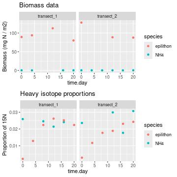

```r
library(ggplot2)
library(gridExtra)
p1 <- ggplot(exp, aes(x = time.day, y = biomass, col = species)) +
    geom_point() + ggtitle("Biomass data") + ylab("Biomass (mg N / m2)") +
    facet_wrap(~ transect)
p2 <- ggplot(exp, aes(x = time.day, y = prop15N, col = species)) +
    geom_point() + ggtitle("Heavy isotope proportions") + ylab("Proportion of 15N")  +
    facet_wrap(~ transect)
grid.arrange(p1, p2, nrow = 2)
```

**Note:** Here the biomass data is given in mg N per m$^2$ of stream bed. For dissolved ammonium, this is done by calculating the quantity of ammonium present in the water column covering one m$^2$, which depends on the stream depth. Here we assume the stream depth is constant during the experiment.

Because the water is constantly flowing in the stream, we will consider that ammonium is in a steady state at the local scale of a transect (i.e. whatever is consumed by epilithon is replenished by the incoming water). The dissolved ammonium is experimentally enriched in $^{15}$N compared to background levels by dripping a solution of $^{15}$N-enriched ammonium at a constant rate upstream of each transect (the dripping starts at the beginning of the experiment). This is why the proportion of $^{15}$N in ammonium is higher than in epilithon at the beginning of the experiment.

As long as the drip is also stable during the experiment, the assumption of steady state for dissolved ammonium holds. We will learn in the next tutorial how we can specify more complicated addition events, such as pulses or on/off drip regimes.

## Building the network model

Let’s start by creating a new network model and specifying its topology:

```r
m <- new_networkModel() %>% set_topo("NH4 -> epilithon")
```

The next step is to define the initial conditions. In our simulated experiment, the data comes from measurements in a stream, not from a controlled aquarium, so the initial conditions are not as certain as in a controlled experiment. We will assume that a good guess for initial biomasses are the mean biomasses measured in each transect:

**Note:** Here we are using some basic functions from the **tidyverse** such as `group_by()`, `filter()`, `summarize()` and `select()` to wrangle the data. This is not compulsory: you can use whatever tool you prefer to build the table of initial conditions needed to build the network model. If you are interested in learning more about the **tidyverse** in general, a good resource in the [R for data science](https://r4ds.had.co.nz/) online book.

```r
init_bm <- exp %>%
    group_by(species, transect) %>%
    summarize(biomass = mean(biomass, na.rm = TRUE))
```

```
## `summarise()` has regrouped the output.
## ℹ Summaries were computed grouped by species and transect.
## ℹ Output is grouped by species.
## ℹ Use `summarise(.groups = "drop_last")` to silence this message.
## ℹ Use `summarise(.by = c(species, transect))` for per-operation grouping (`?dplyr::dplyr_by`) instead.
```

```r
init_bm
```

```
## # A tibble: 4 × 3
## # Groups:   species [2]
##   species   transect   biomass
##   <chr>     <chr>        <dbl>
## 1 NH4       transect_1   0.33
## 2 NH4       transect_2   0.303
## 3 epilithon transect_1  93.9
## 4 epilithon transect_2 101.
```

For the initial proportion of $^{15}$N in the dissolved ammonium, we will also use mean values since we expect ammonium to be in a steady state during the experiment (the drip is on during the whole experiment):

```r
init_prop_NH4 <- exp %>%
    filter(species == "NH4") %>%
    group_by(transect, species) %>%
    summarize(prop15N = mean(prop15N, na.rm = TRUE))
```

```
## `summarise()` has regrouped the output.
## ℹ Summaries were computed grouped by transect and species.
## ℹ Output is grouped by transect.
## ℹ Use `summarise(.groups = "drop_last")` to silence this message.
## ℹ Use `summarise(.by = c(transect, species))` for per-operation grouping (`?dplyr::dplyr_by`) instead.
```

```r
init_prop_NH4
```

```
## # A tibble: 2 × 3
## # Groups:   transect [2]
##   transect   species prop15N
##   <chr>      <chr>     <dbl>
## 1 transect_1 NH4      0.024
## 2 transect_2 NH4      0.0255
```

For the epilithon, we know that the proportion of $^{15}$N will increase during the experiment, so our best guess is to use only the proportion measured at $t_0$:

```r
init_prop_epi <- exp %>%
    filter(species == "epilithon" & time.day == 0) %>%
    select(species, prop15N, transect)
init_prop_epi
```

```
## # A tibble: 2 × 3
##   species   prop15N transect
##   <chr>       <dbl> <chr>
## 1 epilithon  0.0022 transect_1
## 2 epilithon  0.0029 transect_2
```

Now we can wrap up all those numbers into a single table containing the initial conditions:

```r
init_prop <- bind_rows(init_prop_NH4, init_prop_epi)
inits <- full_join(init_bm, init_prop)
inits
```

```
## # A tibble: 4 × 4
## # Groups:   species [2]
##   species   transect   biomass prop15N
##   <chr>     <chr>        <dbl>   <dbl>
## 1 NH4       transect_1   0.33   0.024
## 2 NH4       transect_2   0.303  0.0255
## 3 epilithon transect_1  93.9    0.0022
## 4 epilithon transect_2 101.     0.0029
```

We can use this table to specify the initial conditions of the model:

```r
m <- m %>% set_init(inits, comp = "species", size = "biomass", prop = "prop15N",
                    group_by = "transect")
```

We finally add all the observations:

```r
m <- m %>% set_obs(exp, time = "time.day")
m
```

```
## # A tibble: 2 × 5
##   topology           initial          observations      parameters       group
##   <list>             <list>           <list>            <list>           <list>
## 1 <topology [2 × 2]> <tibble [2 × 3]> <tibble [12 × 4]> <tibble [5 × 2]> <chr [1]>
## 2 <topology [2 × 2]> <tibble [2 × 3]> <tibble [12 × 4]> <tibble [5 × 2]> <chr [1]>
```

Let’s check the grouping structure of our model:

```r
groups(m)
```

```
## # A tibble: 2 × 1
##   transect
##   <chr>
## 1 transect_1
## 2 transect_2
```

Good!

### Specifying steady-state compartments

The last step before we can run the MCMC is to specify that the NH$_4^+$ compartment is in steady state. Let’s have a look at the current topology of the model:

```r
topo(m)
```

```
## <2 comps>
##           epilithon NH4
## epilithon         0   1
## NH4               0   0
```

All compartments in the current topology are “standard” compartments (i.e. not in imposed steady-state). We use the `set_steady()` function to indicate which compartments are to be considered into steady-state:

```r
m <- m %>% set_steady(comps = "NH4")
```

`NH4` is set to steady-state: the compartment size and the proportion of $^{15}$N for `NH4` will be considered constant within each replicate. Let’s look again at the topology:

```r
topo(m)
```

```
## <2 comps>
##           epilithon NH4*
## epilithon         0    1
## NH4*              0    0
## [ * : steady-state]
```

NH$_4^+$ is now marked with an asterisk, which indicates a steady state compartment. We are ready to run the MCMC.

## Running the MCMC

As usual, we need to specify the priors for the parameters we will be sampling during MCMC run:

```r
priors(m)
```

```
## # A tibble: 5 × 2
##   in_model                 prior
##   <chr>                    <list>
## 1 eta                      <NULL>
## 2 lambda_epilithon         <NULL>
## 3 lambda_NH4               <NULL>
## 4 upsilon_NH4_to_epilithon <NULL>
## 5 zeta                     <NULL>
```

Since NH$_4^+$ is in a steady state in the model, the `lambda_NH4` parameter will not influence the likelihood of the model, so let’s just set it to a constant so that the sampler does not waste efforts on it:

```r
m <- set_priors(m, constant_p(0), "lambda_NH4")
```

The observation times were in days, and it is unlikely than the loss rate for epilithon will be more than 1 per day, so `normal_p(0, 1)` is quite generous:

```r
m <- set_priors(m, normal_p(0, 1), "lambda_epilithon")
```

What about `upsilon_NH4_to_epilithon`? NH4 is a small compartment, but it is in steady state because it is constantly renewed by the stream flow. This means that the uptake rate from this compartment can be very large, without depleting it.

To get an idea of how big it could be, how large would it need to be to renew all of epilithon compartment during a day? For an epilithon biomass of 100 and an NH4 biomass of 0.3, the rate would need to be about 333 per day. Let’s set a prior which would allow it but with a lot more probability mass below 333:

```r
m <- set_prior(m, normal_p(0, 350), "upsilon_NH4_to_epilithon")
```

```
## Prior modified for parameter(s):
##   - upsilon_NH4_to_epilithon
```

Finally, here `eta` and `zeta` represent coefficients of variation for the observations. A reasonable prior could be:

```r
# "eta" will match both `eta` and `zeta`
m <- set_priors(m, normal_p(0, 5), "eta")
```

Let’s have a look at all our priors and then run the model:

```r
priors(m)
```

```
## # A tibble: 5 × 2
##   in_model                 prior
##   <chr>                    <list>
## 1 eta                      <trun_normal(mean=0,sd=5)>
## 2 lambda_epilithon         <trun_normal(mean=0,sd=1)>
## 3 lambda_NH4               <constant(value=0)>
## 4 upsilon_NH4_to_epilithon <trun_normal(mean=0,sd=350)>
## 5 zeta                     <trun_normal(mean=0,sd=5)>
```

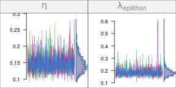

```r
run <- run_mcmc(m, iter = 1000)
plot(run)
# Note: the figure below only shows a few of the traceplots for vignette concision
```

The traces look good. Let’s do a posterior predictive check to ensure that the model makes sense:

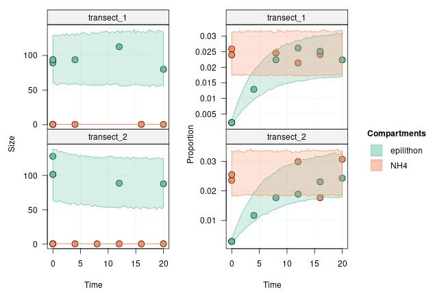

```r
predictions <- predict(m, run)
plot(predictions, facet_row = "group")
```

Let’s use a log scale on the y axis to make visualization of the two compartments in the same plots easier:

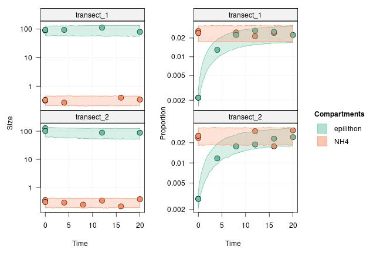

```r
plot(predictions, facet_row = "group", log = TRUE)
```

The model looks ok.

In the next tutorial, you will learn how to specify more complex addition regimes using pulse and drip events.